# Analyse des données NARR

Mathis Deronzier LSCE

5/20/2021

# Traitement des données

## Downscale des données

### Quelques fonctions utiles dans l’analyse

On importe les librairies nécessaires au traitement des données.

```r
#library(ggplot2) #Pour plot les différents graphiques
#On commence par se mettre dans le bon repertoire
WDs<-c("C:/Users/mathisDeronzier/Mathématiques/Stage LSCE downscaling upscaling/stage/NARR datas/R_codes","/home/users/mderon/R_codes")
wd<-WDs[1]
setwd(wd)

#On set la localisation
localisations<- c(".","/home/hydrogeol2/mderon/NARR_1979_2014")#Les localisations possibles
loc<-localisations[1]

#Importation des fonctions de jours sec et de jours de pluie + RMSE
source(paste(loc,"/codes_utiles/Analysis_functions.R", sep=""))
source(paste(loc,"/codes_utiles/downscaling_application.R", sep=""))
source(paste(loc,"/codes_utiles/downscaling_application2.R", sep=""))
#Importation des fonctions de downscaling utiles
#source(paste(loc,"/ds_fun/CDFt.R", sep=""))
#source(paste(loc,"/ds_fun/SSR_CDFt.R", sep=""))
#source(paste(loc,"/ds_fun/CDFt_norm.R", sep=""))
```

### Aplication des fonctions de downscaling

```r
programmes<- c("CDFt","SSR_CDFt", "CDFt_norm") #Liste des programmes permettant de downscaler
prog<-programmes[1]
D_proj<-TRUE
downscal_appli(loc, prog, D_proj)
```

```
## running month = 1
## running month = 2
## running month = 3
## running month = 4
## running month = 5
## running month = 6
## running month = 7
## running month = 8
## running month = 9
## running month = 10
## running month = 11
## running month = 12
```

### Importation des données

```r
DATES <- read.csv(paste(loc,"/series/dates_1979_2014.csv", sep=""))[,(2:4)]
#On fixe les dates de calibration et de projection
if (D_proj){
    proj <- which (DATES[,1]>=1996)
}
if(D_proj==FALSE){
   proj <- which (DATES[,1]<1996)
}

#PRECIPITATION
pr_ds1 <- read.csv("./series/pr_ds1.csv")[,2]
pr_ds2 <- read.csv("./series/pr_ds2.csv")[,2]
pr_ds3 <- read.csv("./series/pr_ds3.csv")[,2]
pr_ds4 <- read.csv("./series/pr_ds4.csv")[,2]
pr_dsI <- read.csv("./series/pr_dsI.csv")[,2]

pr_deg1 <- read.csv("./series/precp_deg1_1979_2014.csv")[proj,2]
pr_deg2 <- read.csv("./series/precp_deg2_1979_2014.csv")[proj,2]
pr_deg3 <- read.csv("./series/precp_deg3_1979_2014.csv")[proj,2]
pr_deg4 <- read.csv("./series/precp_deg4_1979_2014.csv")[proj,2]

pr_ref <- read.csv("./series/precp_ref_1979_2014.csv")[proj,2]

pr_IPSL <- read.csv("./series/IPSL_pr_1979_2014.csv")[proj,]


#ETP
etp_ds1 <- read.csv("./series/etp_ds1.csv")[,2]
etp_ds2 <- read.csv("./series/etp_ds2.csv")[,2]
etp_ds3 <- read.csv("./series/etp_ds3.csv")[,2]
etp_ds4 <- read.csv("./series/etp_ds4.csv")[,2]
etp_dsI <- read.csv("./series/etp_dsI.csv")[,2]

etp_deg1 <- read.csv(paste(loc,"/series/evap_deg1_1979_2014.csv",sep=""))[proj,2]
etp_deg2 <- read.csv(paste(loc,"/series/evap_deg2_1979_2014.csv",sep=""))[proj,2]
etp_deg3 <- read.csv(paste(loc,"/series/evap_deg3_1979_2014.csv",sep=""))[proj,2]
etp_deg4 <- read.csv(paste(loc,"/series/evap_deg4_1979_2014.csv",sep=""))[proj,2]

etp_ref <- read.csv("./series/evap_ref_1979_2014.csv")[proj,2]

etp_IPSL <- read.csv("./series/IPSL_etp_1979_2014.csv")[proj,]

#On cree la liste de chaque de toutes les series etudiees

#Precipitation
pr_series<-matrix(0, length(pr_ref),11)
pr_series[,1]<-pr_ref
pr_series[,2]<-pr_ds1
pr_series[,3]<-pr_ds2
pr_series[,4]<-pr_ds3
pr_series[,5]<-pr_ds4
pr_series[,6]<-pr_dsI
pr_series[,7]<-pr_deg1
pr_series[,8]<-pr_deg2
pr_series[,9]<-pr_deg3
pr_series[,10]<-pr_deg4
pr_series[,11]<-1e5*pr_IPSL

colnames(pr_series)<-c("ref", "dwnsc(x9)", "dwnsc(x25)", "dwnsc(x49)", "dwnsc(x81)", "dwnsc IPSL",  "deg(x9)", "deg(x25)", "deg(x49)", "deg(x81)", "IPSL")

#ETP
etp_series<-matrix(0, length(pr_ref),11)
etp_series[,1]<-etp_ref
etp_series[,2]<-etp_ds1
etp_series[,3]<-etp_ds2
etp_series[,4]<-etp_ds3
etp_series[,5]<-etp_ds4
etp_series[,6]<-etp_dsI
etp_series[,7]<-etp_deg1
etp_series[,8]<-etp_deg2
etp_series[,9]<-etp_deg3
etp_series[,10]<-etp_deg4
etp_series[,11]<-1e5*etp_IPSL
colnames(etp_series)<-c("ref", "dwnsc(x9)", "dwnsc(x25)", "dwnsc(x49)", "dwnsc(x81)", "dwnsc IPSL", "deg(x9)", "deg(x25)", "deg(x49)", "deg(x81)", "IPSL")
```

#### Etude classique des séries temporelle

```r
summary(pr_series)
```

```
##       ref             dwnsc(x9)          dwnsc(x25)         dwnsc(x49)
##  Min.   :  0.0000   Min.   :  0.0000   Min.   :  0.0000   Min.   : 0.000
##  1st Qu.:  0.0000   1st Qu.:  0.0000   1st Qu.:  0.0000   1st Qu.: 0.000
##  Median :  0.0076   Median :  0.0000   Median :  0.0000   Median : 0.000
##  Mean   :  2.1929   Mean   :  2.2832   Mean   :  2.3153   Mean   : 2.320
##  3rd Qu.:  0.5156   3rd Qu.:  0.5564   3rd Qu.:  0.6132   3rd Qu.: 0.673
##  Max.   :137.1719   Max.   :133.9089   Max.   :118.7585   Max.   :93.853
##    dwnsc(x81)         dwnsc IPSL         deg(x9)             deg(x25)
##  Min.   : 0.00000   Min.   :-0.8164   Min.   :  0.00000   Min.   :  0.00000
##  1st Qu.: 0.00000   1st Qu.: 0.0339   1st Qu.:  0.00000   1st Qu.:  0.00118
##  Median : 0.02475   Median : 0.4843   Median :  0.01101   Median :  0.02040
##  Mean   : 2.30765   Mean   : 2.6378   Mean   :  2.17765   Mean   :  2.16086
##  3rd Qu.: 0.74698   3rd Qu.: 1.0469   3rd Qu.:  0.65191   3rd Qu.:  0.85752
##  Max.   :68.71523   Max.   :94.3209   Max.   :133.29861   Max.   :117.73500
##     deg(x49)           deg(x81)             IPSL
##  Min.   : 0.00000   Min.   : 0.00000   Min.   :  0.0000
##  1st Qu.: 0.00200   1st Qu.: 0.00303   1st Qu.:  0.0000
##  Median : 0.03321   Median : 0.05257   Median :  0.0000
##  Mean   : 2.14162   Mean   : 2.12269   Mean   :  2.6001
##  3rd Qu.: 1.05746   3rd Qu.: 1.28757   3rd Qu.:  0.8324
##  Max.   :92.81107   Max.   :67.91580   Max.   :117.9540
```

```r
summary(etp_series)
```

```
##       ref           dwnsc(x9)        dwnsc(x25)       dwnsc(x49)
##  Min.   :-1.657   Min.   :-2.625   Min.   :-2.625   Min.   :-2.572
##  1st Qu.: 3.105   1st Qu.: 3.113   1st Qu.: 3.113   1st Qu.: 3.102
##  Median : 5.656   Median : 5.682   Median : 5.682   Median : 5.665
##  Mean   : 6.062   Mean   : 6.088   Mean   : 6.088   Mean   : 6.088
##  3rd Qu.: 8.454   3rd Qu.: 8.522   3rd Qu.: 8.522   3rd Qu.: 8.544
##  Max.   :30.613   Max.   :32.933   Max.   :32.933   Max.   :32.505
##    dwnsc(x81)       dwnsc IPSL        deg(x9)          deg(x25)
##  Min.   :-2.999   Min.   :-3.316   Min.   :-1.451   Min.   :-1.289
##  1st Qu.: 3.106   1st Qu.: 3.116   1st Qu.: 3.112   1st Qu.: 3.155
##  Median : 5.667   Median : 5.470   Median : 5.695   Median : 5.768
##  Mean   : 6.086   Mean   : 6.129   Mean   : 6.088   Mean   : 6.150
##  3rd Qu.: 8.530   3rd Qu.: 8.471   3rd Qu.: 8.494   3rd Qu.: 8.583
##  Max.   :32.157   Max.   :94.564   Max.   :31.345   Max.   :31.482
##     deg(x49)         deg(x81)           IPSL
##  Min.   :-1.151   Min.   :-1.004   Min.   :  0.01349
##  1st Qu.: 3.133   1st Qu.: 3.140   1st Qu.:  4.84199
##  Median : 5.749   Median : 5.772   Median : 10.13026
##  Mean   : 6.131   Mean   : 6.133   Mean   : 16.07086
##  3rd Qu.: 8.592   3rd Qu.: 8.595   3rd Qu.: 19.57918
##  Max.   :31.137   Max.   :30.819   Max.   :154.79485
```

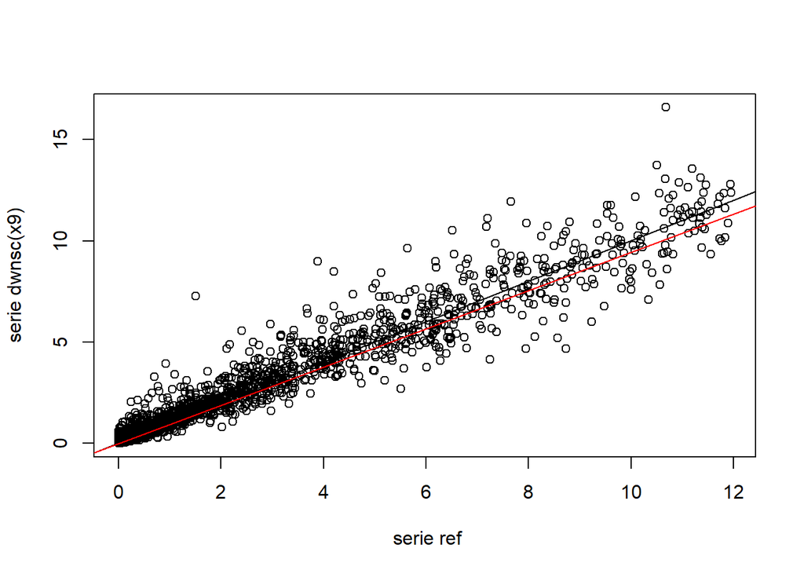

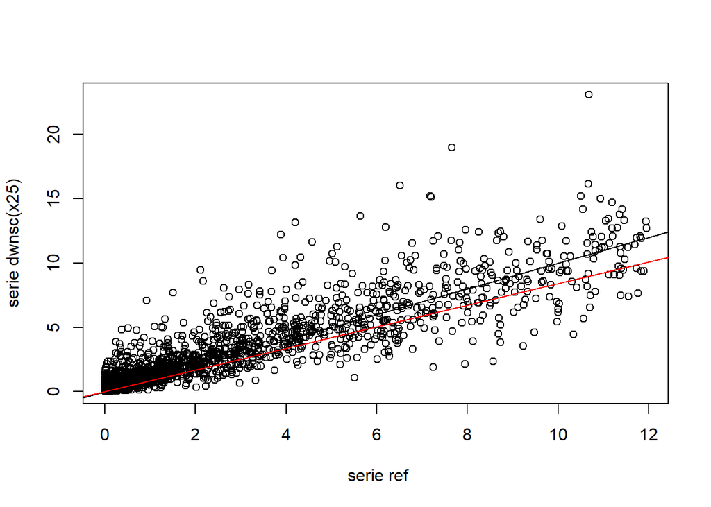

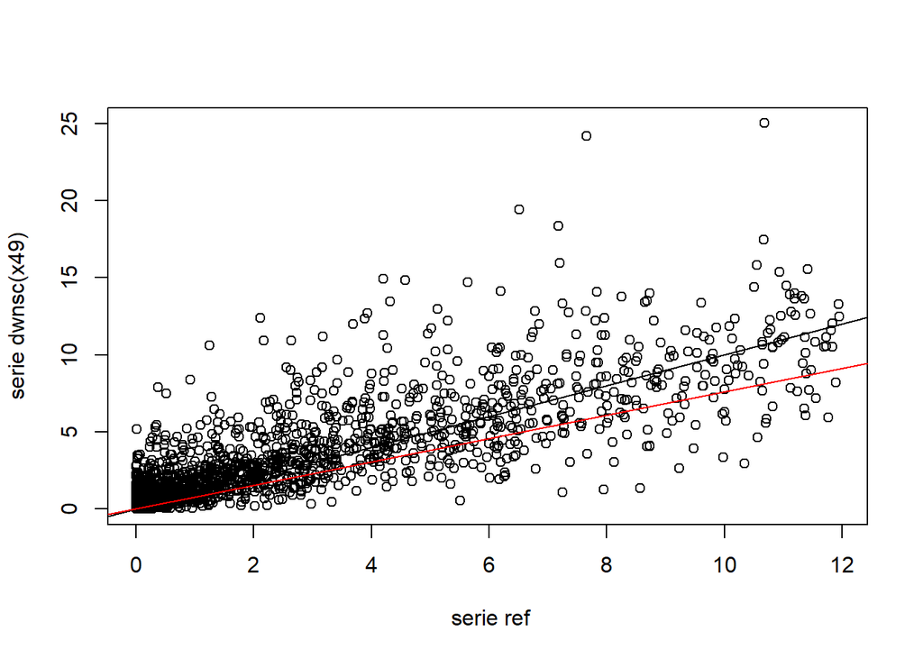

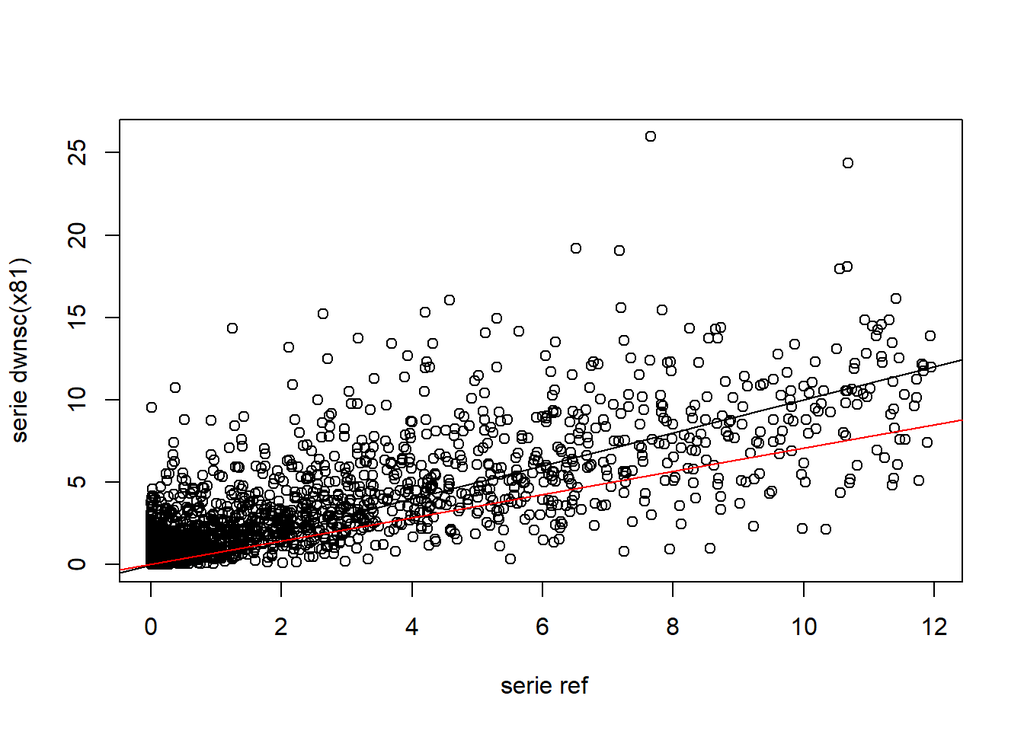

```r
#Tracé des précipitations

for (i in 2:5){
  plot(pr_series[which(pr_series[,1]<12),1],pr_series[which(pr_series[,1]<12),i+5], ylab=paste("serie dwnsc(x",(2*i-1)^2,")",sep=""), xlab=" serie ref")
  abline(0,1)
  mod<-lm(pr_series[which(pr_series[,1]<12),1]~pr_series[which(pr_series[,1]<12),i+5])
  abline(mod$coeff[1], mod$coeff[2], col="red")
}
```

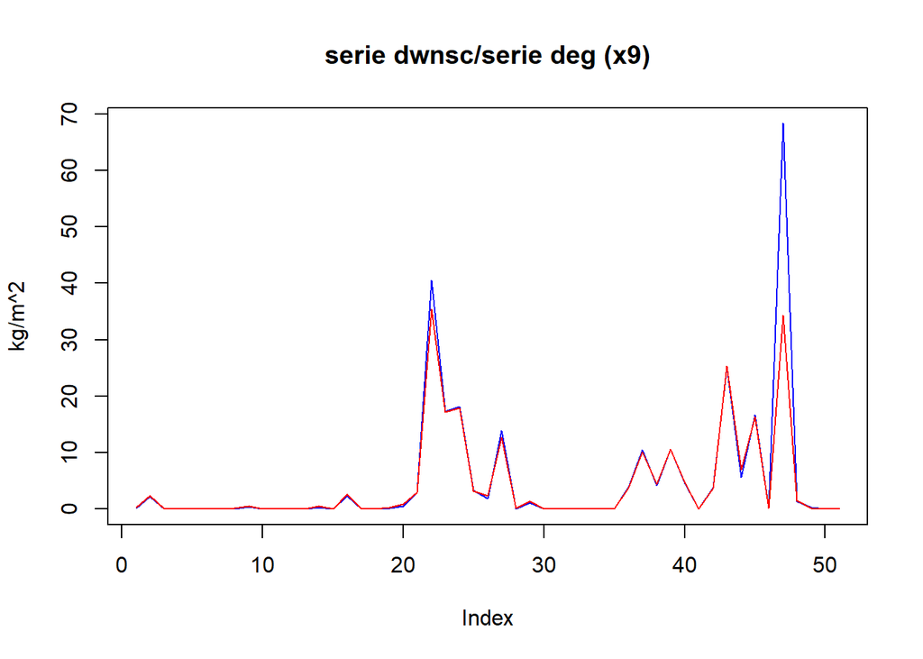

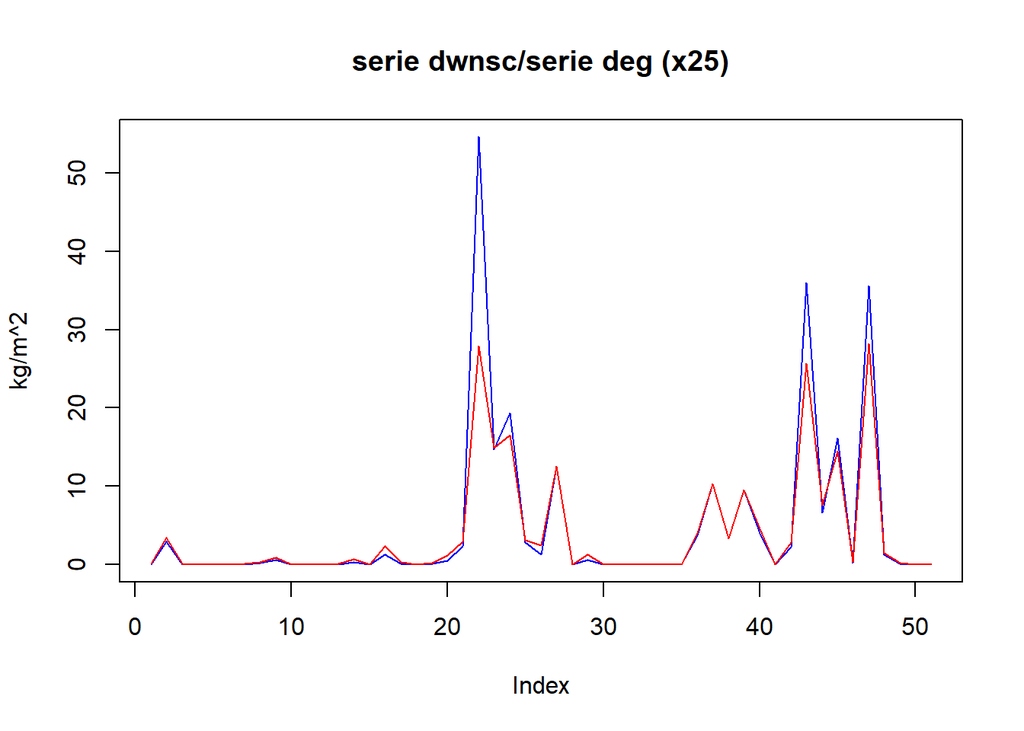

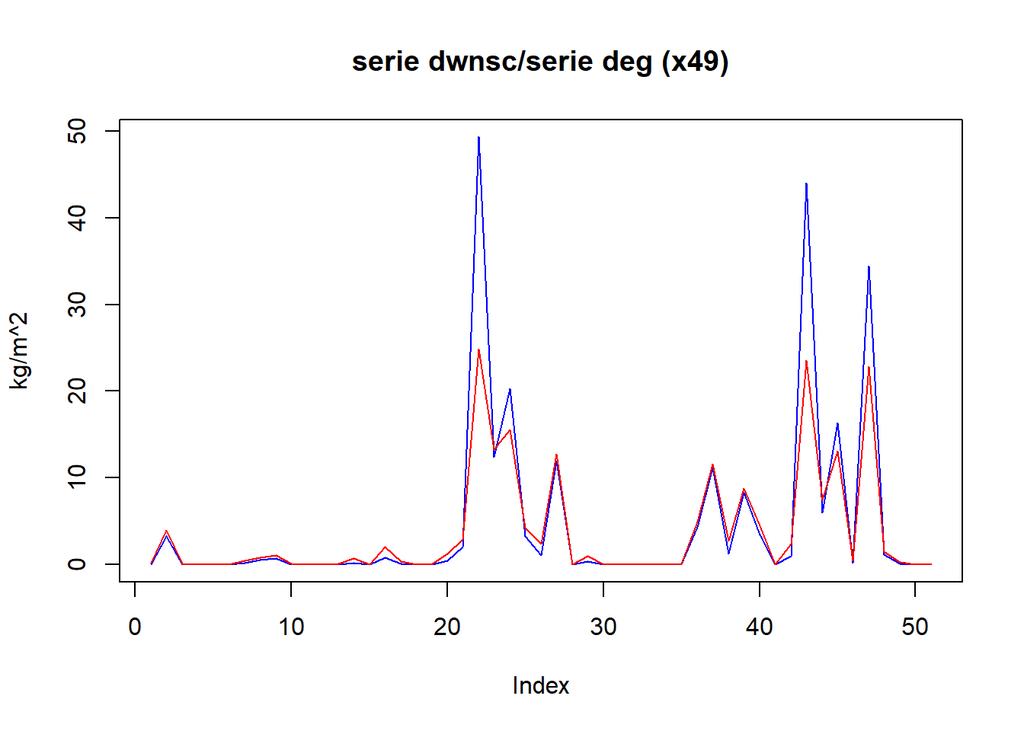

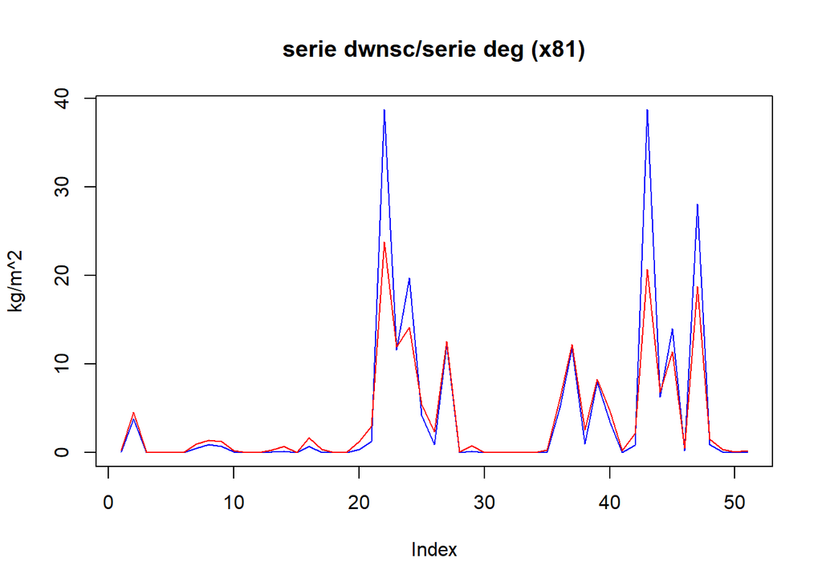

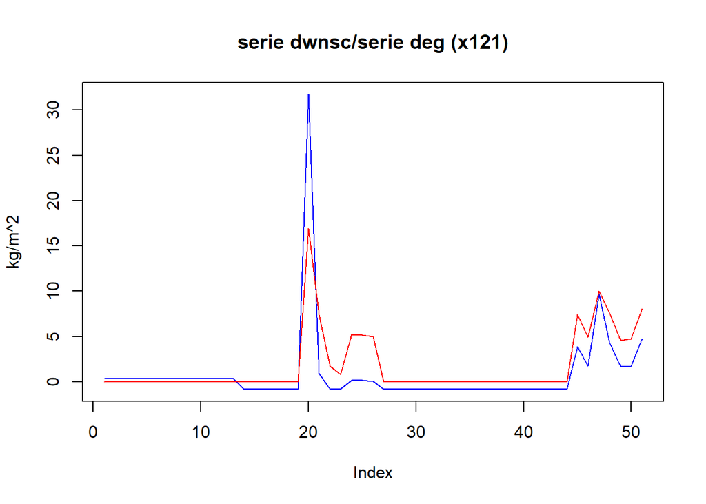

```r
for (i in 2:6){
  plot(pr_series[(170:220),i], type = "l", col= "blue", main= paste("serie dwnsc/serie deg (x",(2*i-1)^2,")",sep=""), ylab="kg/m^2")
  lines(pr_series[(170:220),i+5], col="red")
}
```

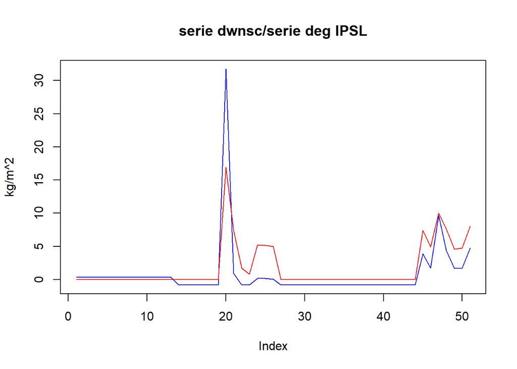

```r
plot(pr_series[(170:220),6], type = "l", col= "blue", main= paste("serie dwnsc/serie deg IPSL"), ylab="kg/m^2")
lines(pr_series[(170:220),11], col="red")
```

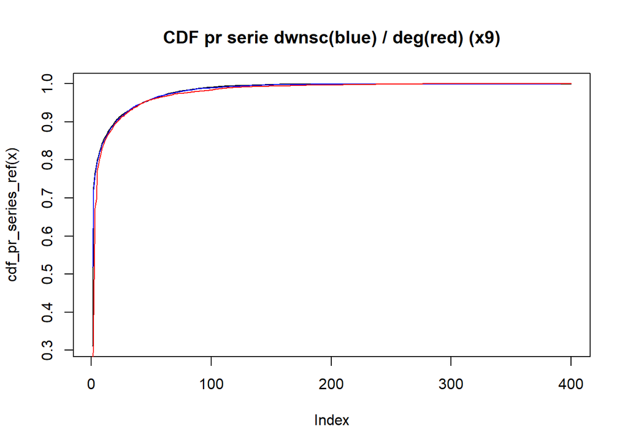

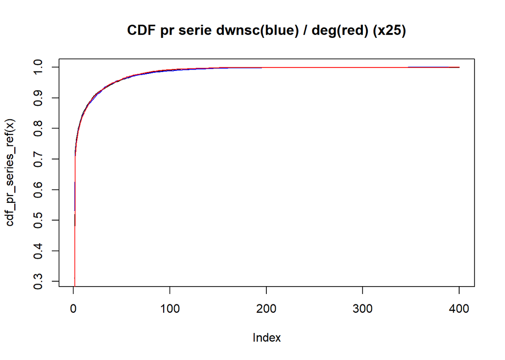

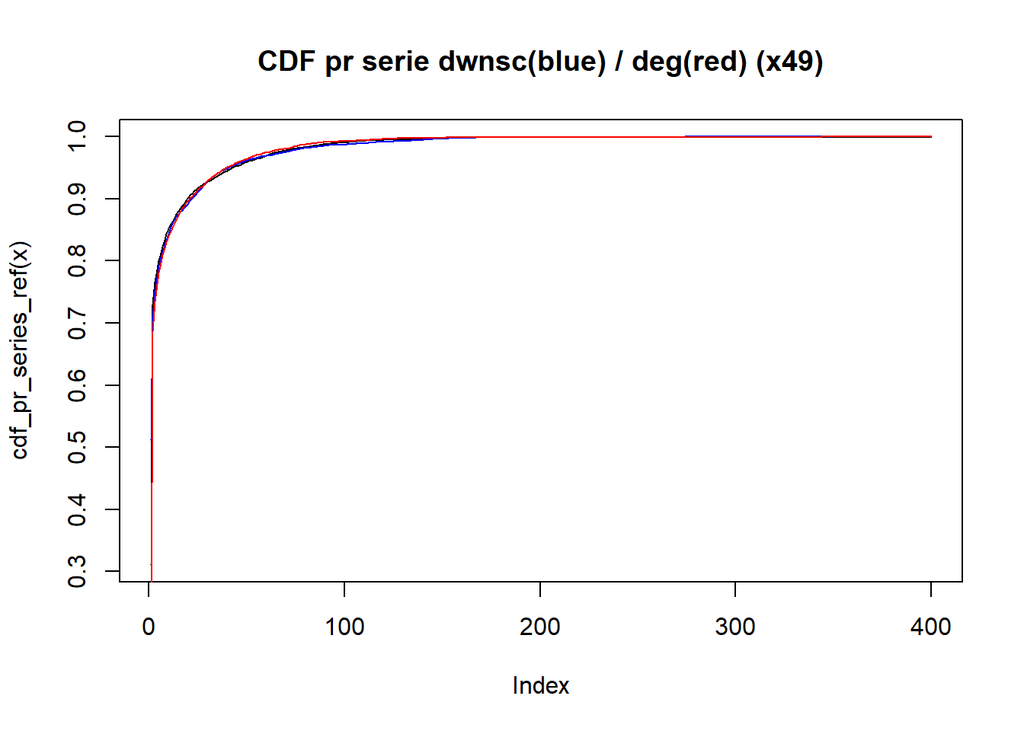

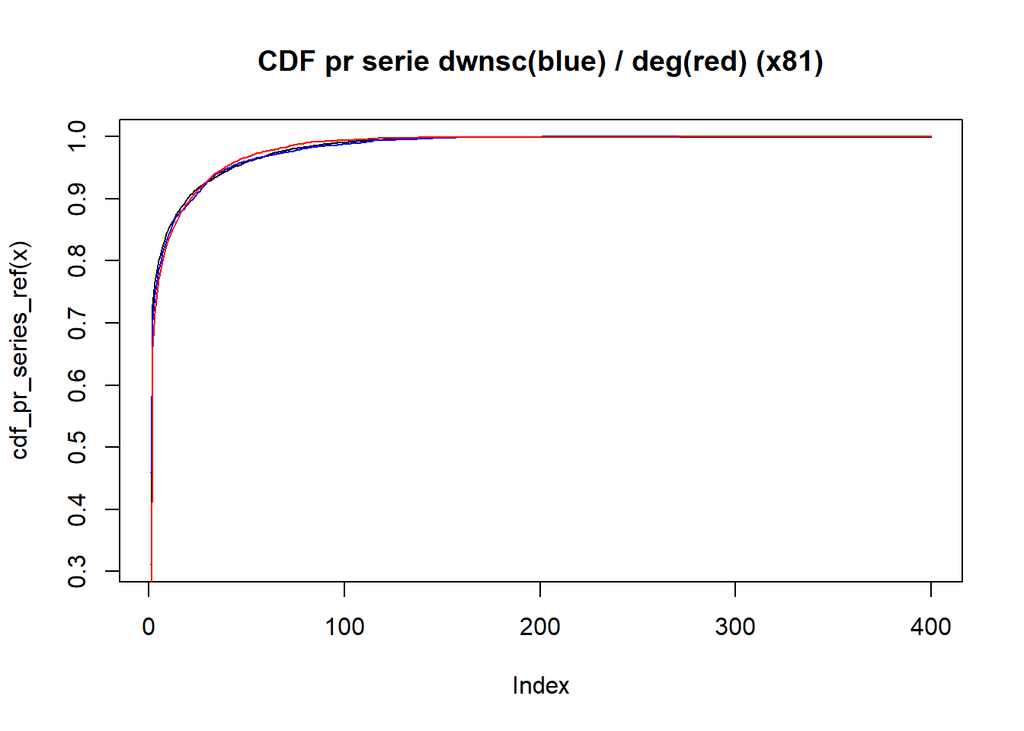

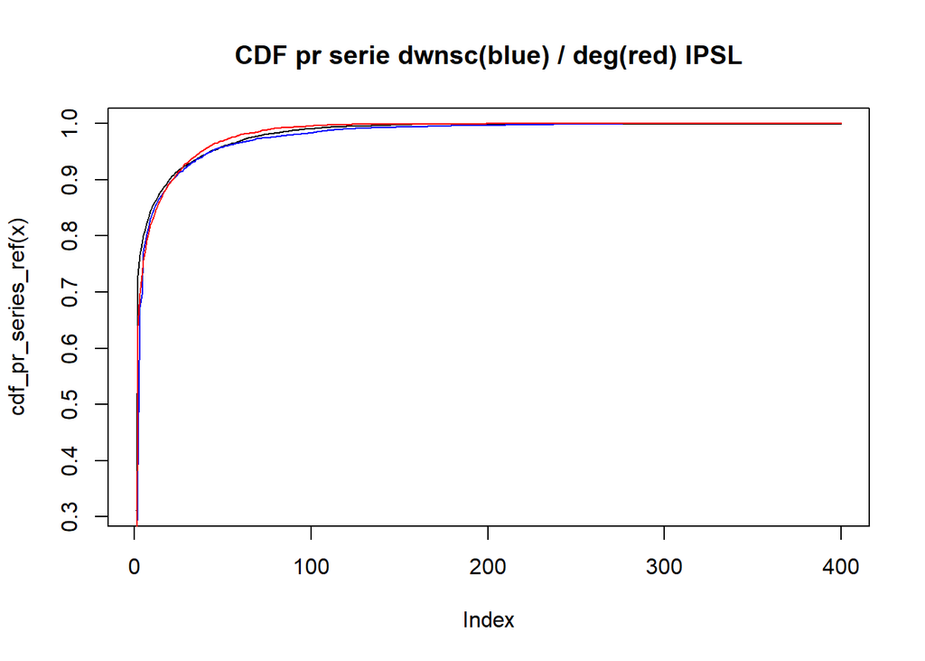

```r
cdf_pr_series_ref<-ecdf(pr_series[,1])

for (i in 2:6){
  if (i<6){
  maxi<-max(pr_series[,1],pr_series[,i], pr_series[,i+5], na.rm = TRUE)
  x<-seq(0,maxi,,400)
  plot(cdf_pr_series_ref(x), main= paste("CDF pr serie dwnsc(blue) / deg(red) (x",(2*i-1)^2,")",sep=""), col="black",type="l")
  cdf_pr_series_dwnsc<-ecdf(pr_series[,i])
  lines(cdf_pr_series_dwnsc(x),col="blue")
  cdf_pr_series_deg<-ecdf(pr_series[,i+4])
  lines(cdf_pr_series_deg(x), col = "red")
  }
  else{
    maxi<-max(pr_series[,1],pr_series[,i], pr_series[,i+5], na.rm = TRUE)
  x<-seq(0,maxi,,400)
  plot(cdf_pr_series_ref(x), main= "CDF pr serie dwnsc(blue) / deg(red) IPSL", col="black",type="l")
  cdf_pr_series_dwnsc<-ecdf(pr_series[,i])
  lines(cdf_pr_series_dwnsc(x),col="blue")
  cdf_pr_series_deg<-ecdf(pr_series[,i+4])
  lines(cdf_pr_series_deg(x), col = "red")
  }
}
```

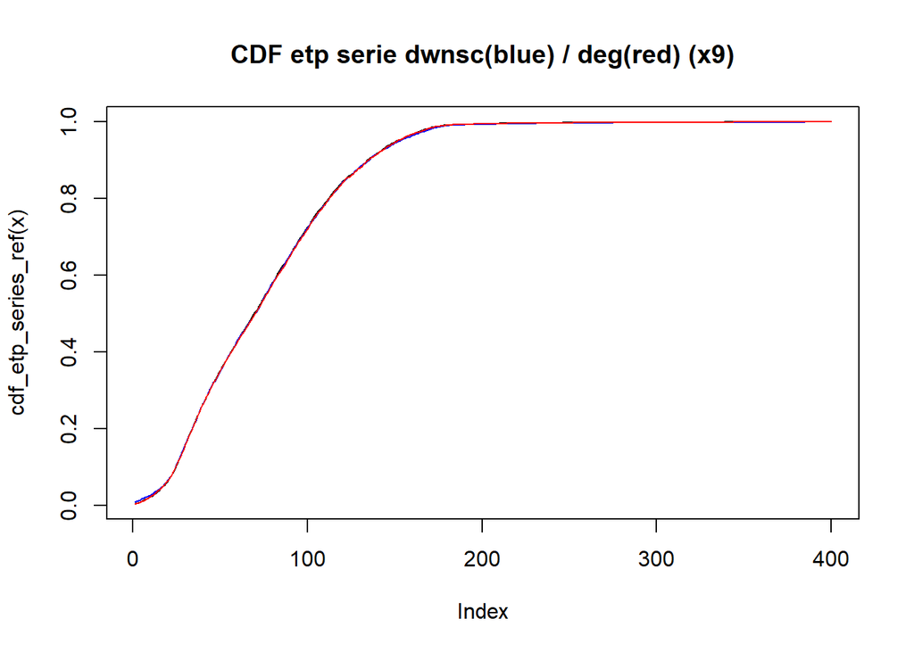

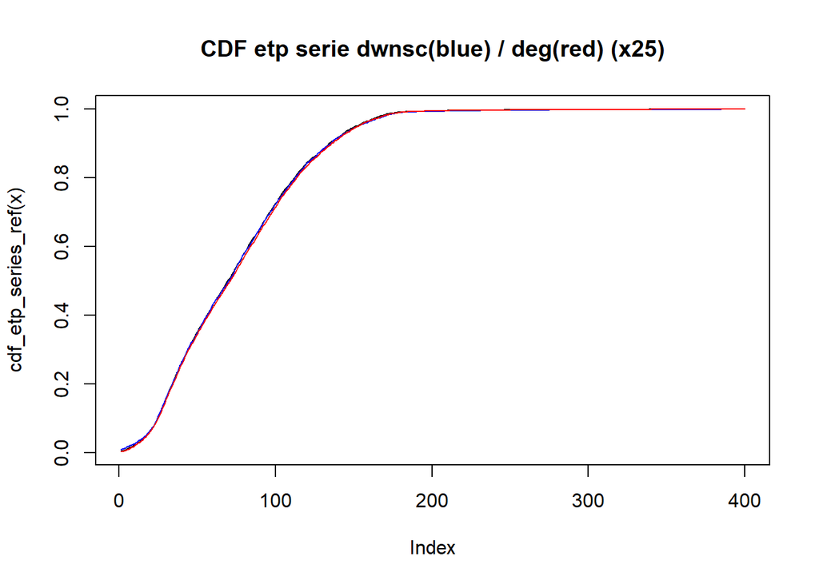

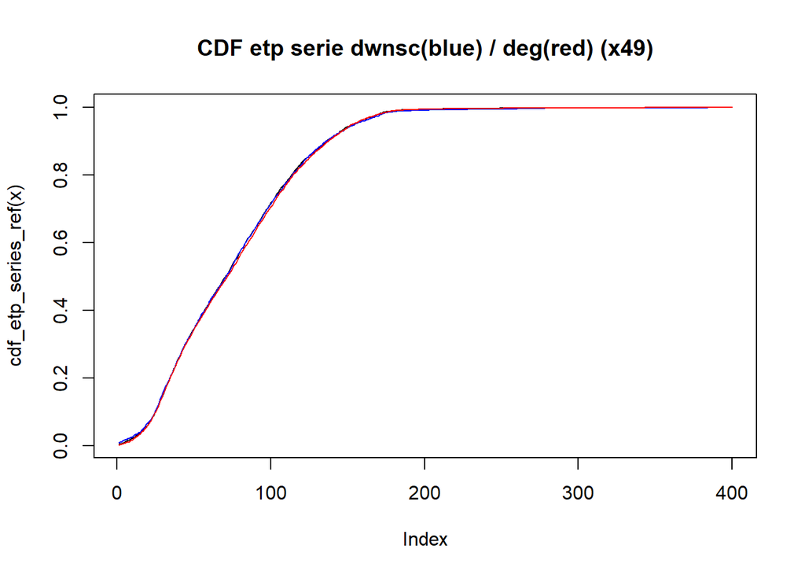

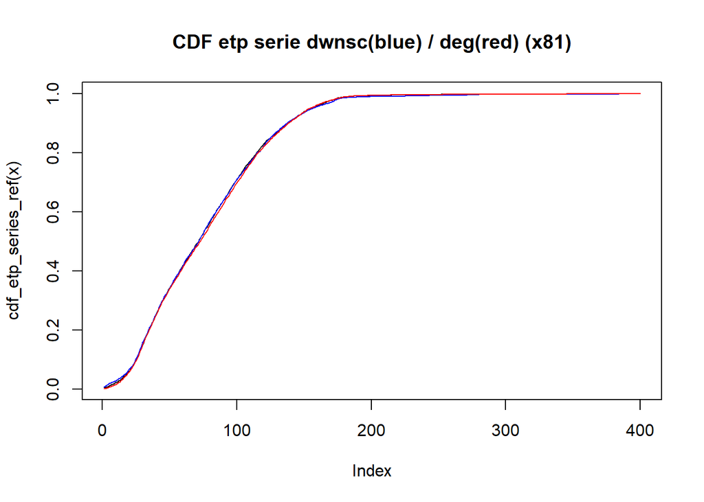

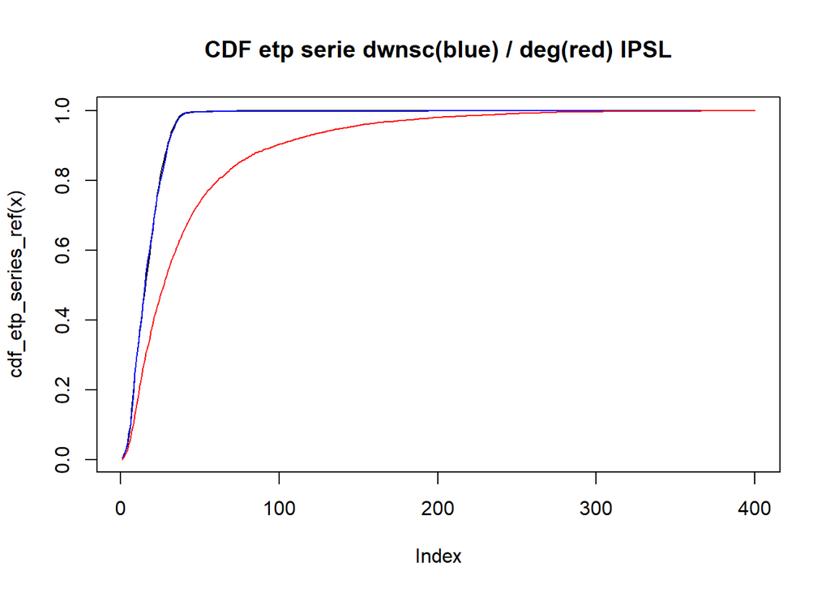

```r
cdf_etp_series_ref<-ecdf(etp_series[,1])
for (i in 2:6){
  if (i<6){
  maxi<-max(etp_series[,1],etp_series[,i], etp_series[,i+5], na.rm = TRUE)
  x<-seq(0,maxi,,400)
  plot(cdf_etp_series_ref(x), main= paste("CDF etp serie dwnsc(blue) / deg(red) (x",(2*i-1)^2,")",sep=""), col="black",type="l")
  cdf_etp_series_dwnsc<-ecdf(etp_series[,i])
  lines(cdf_etp_series_dwnsc(x),col="blue")
  cdf_etp_series_deg<-ecdf(etp_series[,i+5])
  lines(cdf_etp_series_deg(x), col = "red")
  }
  else{
  maxi<-max(etp_series[,1],etp_series[,i], etp_series[,i+5], na.rm = TRUE)
  x<-seq(0,maxi,,400)
  plot(cdf_etp_series_ref(x), main= "CDF etp serie dwnsc(blue) / deg(red) IPSL", col="black",type="l")
  cdf_etp_series_dwnsc<-ecdf(etp_series[,i])
  lines(cdf_etp_series_dwnsc(x),col="blue")
  cdf_etp_series_deg<-ecdf(etp_series[,i+5])
  lines(cdf_etp_series_deg(x), col = "red")
  }
}
```

### RMSE

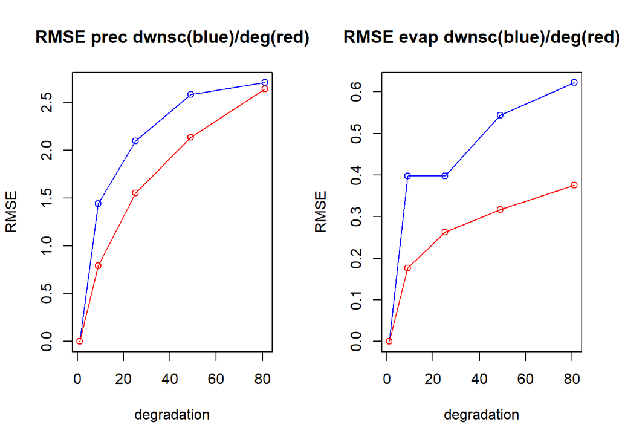

```r
#On va regarder la norme (RMSE)
fun_pr<-function(serie) sqrt(mean((serie-pr_series[,1])^2))
fun_etp<-function(serie) sqrt(mean((serie-etp_series[,1])^2))

pr_RMSE_dwnsc <- apply(pr_series[,(1:5)] ,2,fun_pr)
pr_RMSE_deg <- apply(pr_series[,c(1,7,8,9,10)] ,2,fun_pr)

etp_RMSE_dwnsc <- apply(etp_series[,(1:5)] ,2,fun_etp)
etp_RMSE_deg <- apply(etp_series[,c(1,7,8,9,10)] ,2,fun_etp)
layout(matrix(1:2,1,2))
plot(c(1,9,25,49,81),pr_RMSE_dwnsc, type="o", main="RMSE prec dwnsc(blue)/deg(red)", ylab = "RMSE", xlab= "degradation", col="blue")
lines(c(1,9,25,49,81),pr_RMSE_deg, type="o", col= "red")


plot(c(1,9,25,49,81),etp_RMSE_dwnsc, type="o", main="RMSE evap dwnsc(blue)/deg(red)", ylab = "RMSE", xlab= "degradation", col="blue")
lines(c(1,9,25,49,81),etp_RMSE_deg, type="o", col= "red")
```

### Tracé de boxplot

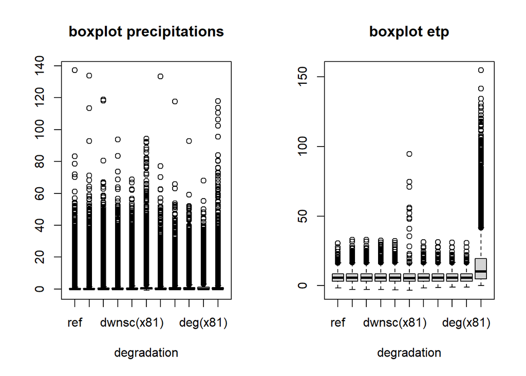

```r
#On va faire un boxplot()
par(mfrow=c(1,2))
boxplot(pr_series, main = "boxplot precipitations", xlab="degradation")
boxplot(etp_series, main = "boxplot etp",xlab="degradation")
```

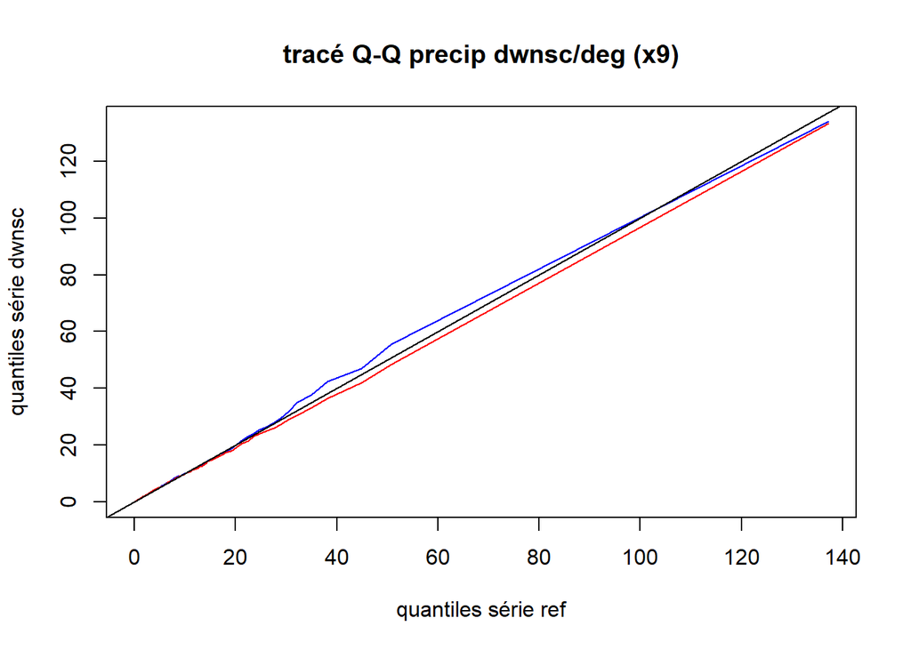

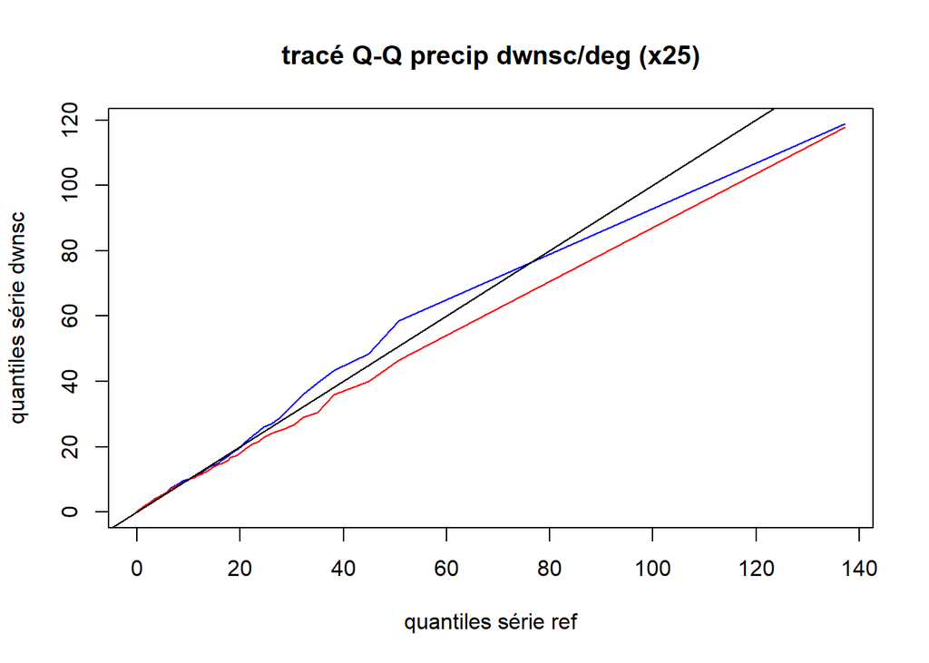

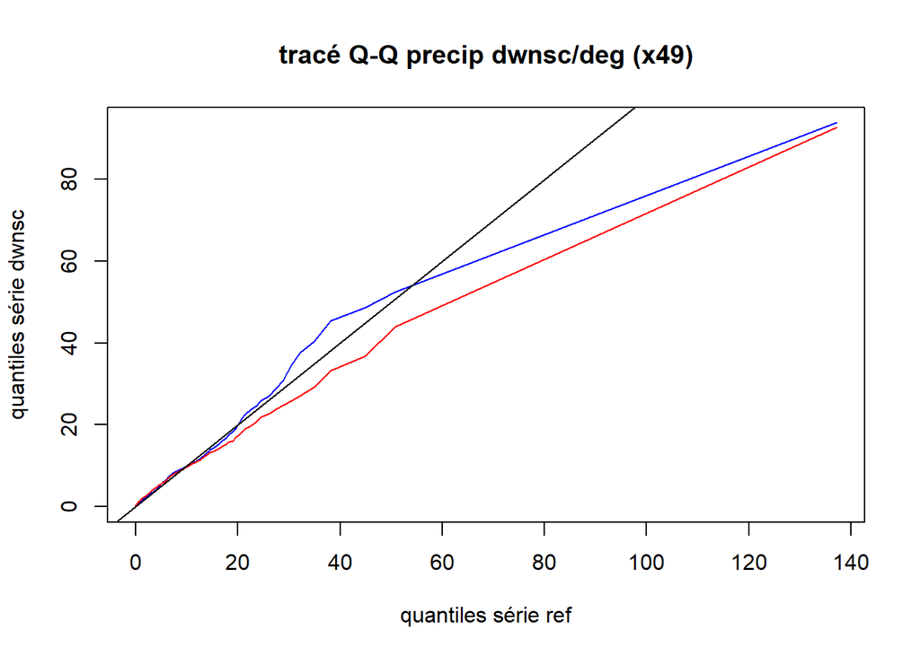

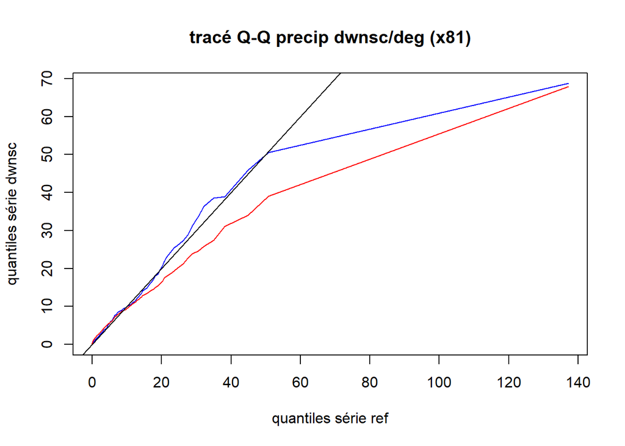

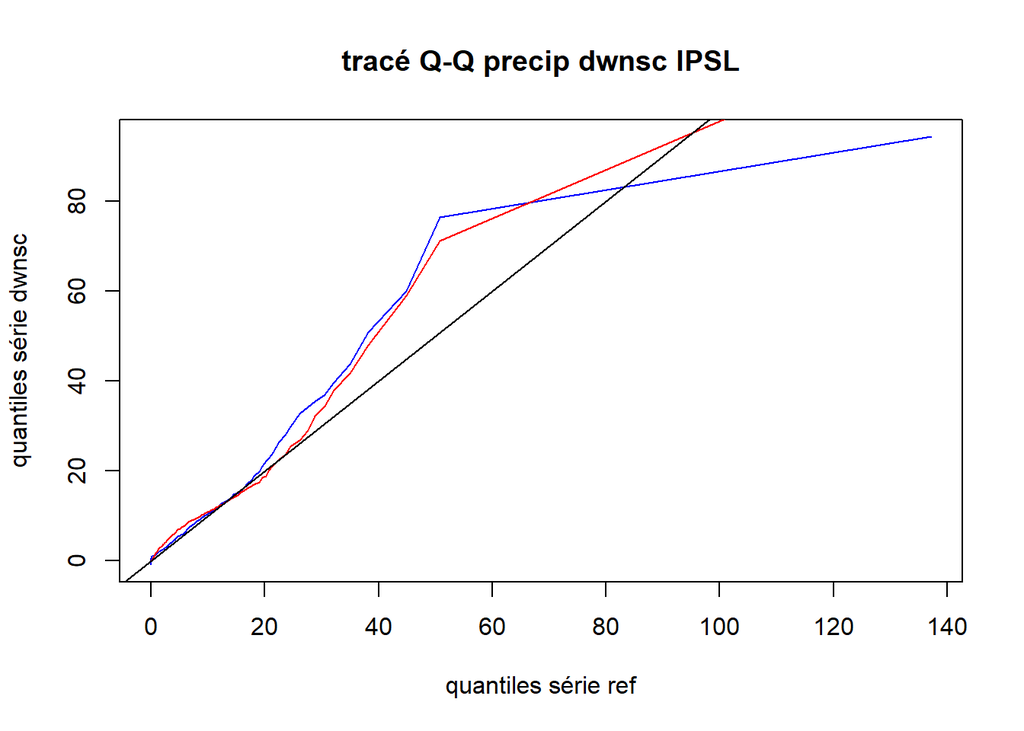

```r
#On veut aussi comparer les quantiles
N=500
Quant<-function(serie){return(quantile(serie,probs=seq(0,1,length.out=N)))}
Quantile_pr_series<-apply(pr_series,2,Quant)
Quantile_etp_series<-apply(etp_series,2,Quant)

for (i in (2:6)){
  if (i<6){
  plot(Quantile_pr_series[,1], Quantile_pr_series[,i], main = paste("tracé Q-Q precip dwnsc/deg (x",(2*(i-1)+1)^2,")",sep=""), xlab = "quantiles série ref", ylab="quantiles série dwnsc", type="l", col="blue")
  lines(Quantile_pr_series[,1], Quantile_pr_series[,i+5], col="red")
  abline(0,1)
  }
  else{
    plot(Quantile_pr_series[,1], Quantile_pr_series[,i],main= "tracé Q-Q precip dwnsc IPSL", xlab = "quantiles série ref", ylab="quantiles série dwnsc", type="l", col="blue")
    lines(Quantile_pr_series[,1], Quantile_pr_series[,i+5], col="red")
    abline(0,1)
  }
}
```

### La correlation temporelle: ACF

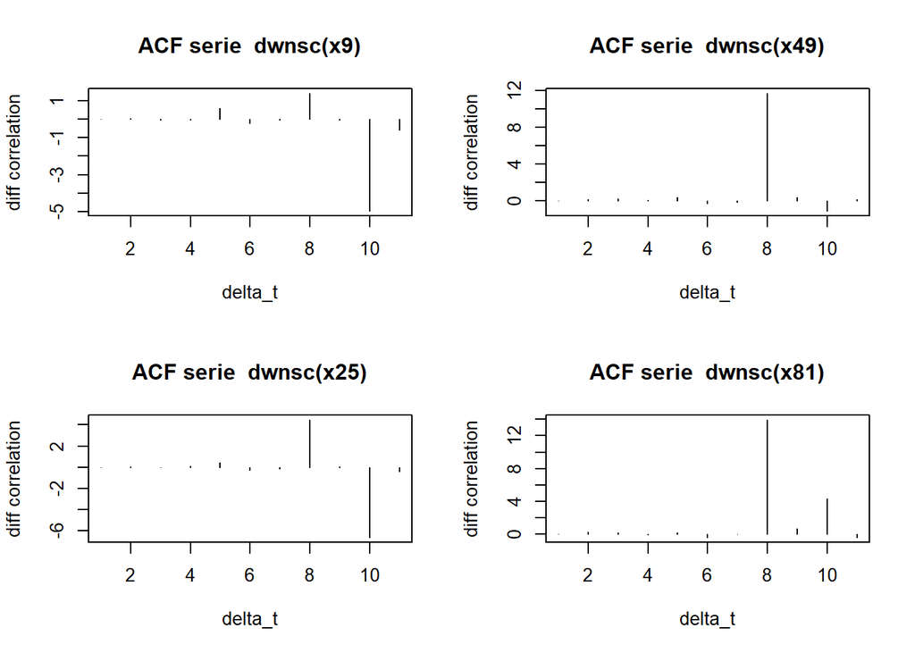

```r
# on va regarder l'autocorrelation sur 10 jours
T=10
delta_t<-(1:(T+1))
ACF_series<-function(serie){return(acf(serie,type="correlation",lag.max=T,plot=FALSE)$acf)}
#Cacul de l'ACF pour les differentes series
ACF_pr_series<- apply(pr_series,2,ACF_series)
ACF_etp_series<-apply(etp_series,2,ACF_series)
#Données des ordonnées
layout(matrix(1:4,2,2))
for (i in 2:6){
  plot(x=delta_t, y=(ACF_pr_series[,i]-ACF_pr_series[,1])/ACF_pr_series[,1], xlab="delta_t", ylab="diff correlation", type="h",col="black", main=paste("ACF serie  dwnsc(x",(2*(i-1)+1)^2,")",sep=""))
}
```

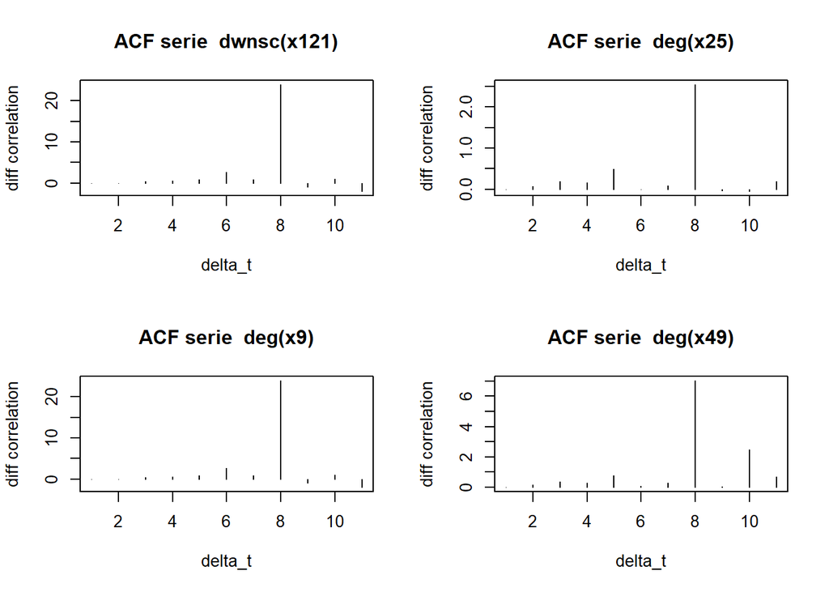

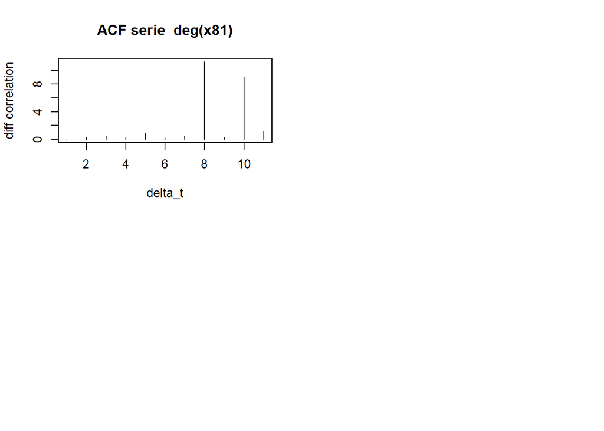

```r
for (i in 6:9){
  plot(x=delta_t, y=(ACF_pr_series[,i]-ACF_pr_series[,1])/ACF_pr_series[,1], xlab="delta_t", ylab="diff correlation", type="h",col="black", main=paste("ACF serie  deg(x",(2*(i-5)+1)^2,")",sep=""))
}
```

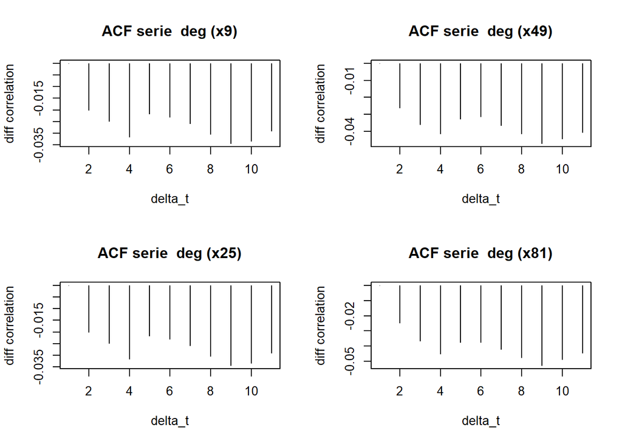

```r
layout(matrix(1:4,2,2))
for (i in 2:5){
  plot(x=delta_t, y=(ACF_etp_series[,i]-ACF_etp_series[,1])/ACF_etp_series[,1], xlab="delta_t", ylab="diff correlation", type="h",col="black", main=paste("ACF serie  deg (x",(2*(i-1)+1)^2,")",sep=""))
}
```

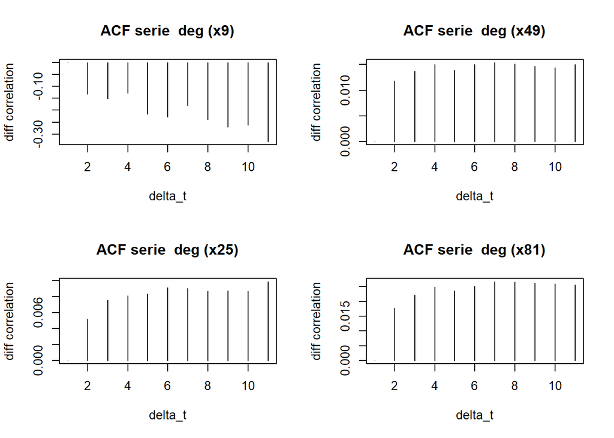

```r
layout(matrix(1:4,2,2))
for (i in 6:9){
  plot(x=delta_t, y=(ACF_etp_series[,i]-ACF_etp_series[,1])/ACF_etp_series[,1], xlab="delta_t", ylab="diff correlation", type="h",col="black", main=paste("ACF serie  deg (x",(2*(i-5)+1)^2,")",sep=""))
}
```

### Conclusion:

#### Analyse des fonctions de distribution

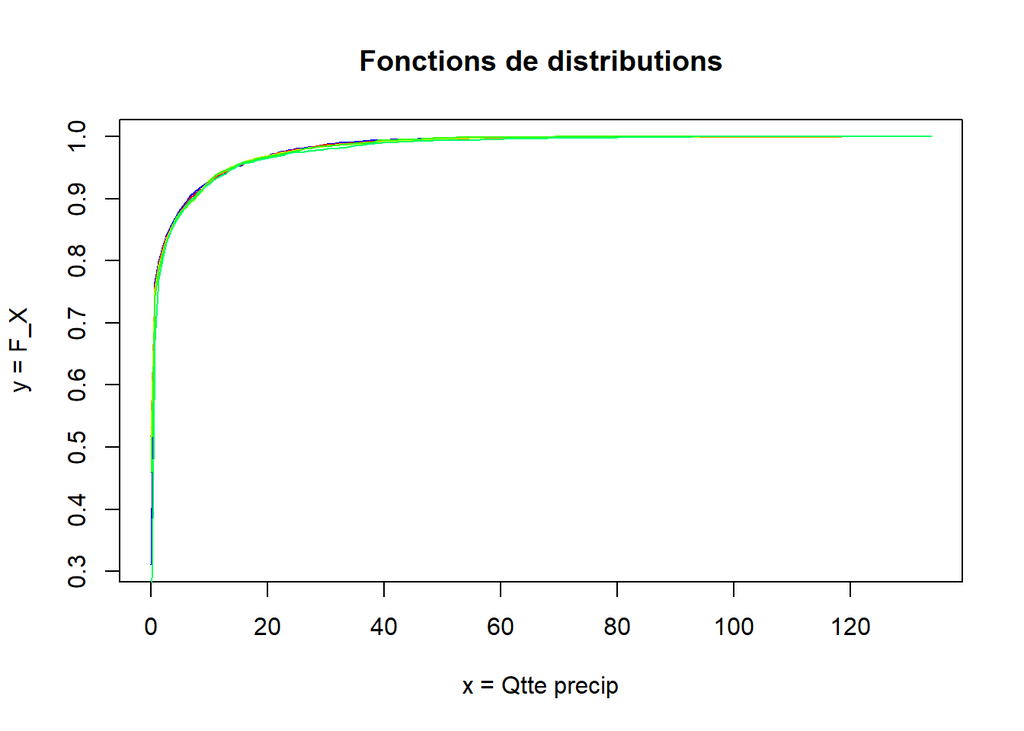

```r
#On commence par afficher les fonctions de répartition empiriques
range_pr <- range(pr_series[,2])
range_etp <- range(etp_series[,2])
CDF_pr_series <- apply(pr_series, 2, ecdf)
CDF_etp_series <- apply(etp_series, 2, ecdf)

x<-seq(range_pr[1],range_pr[2],length.out=200)
colors<-rainbow(10)

#On va afficher toutes les fonctions de répartition sur un même graphique.



plot(x,CDF_pr_series$ref(x),xlab="x = Qtte precip", ylab="y = F_X", type="l",col="blue", main= "Fonctions de distributions")
for (i in 2:6){
  eval(parse(text=paste("y <- CDF_pr_series[[",i,"]]","(x)",sep="")))
  lines(x,y, col = colors[i-1])
}
```

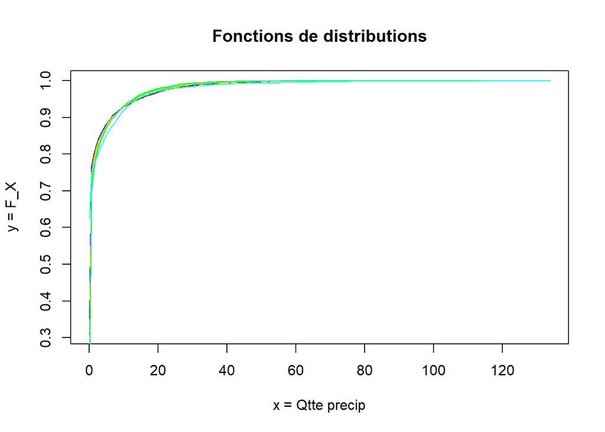

```r
plot(x,CDF_pr_series$ref(x),xlab="x = Qtte precip", ylab="y = F_X", type="l",col="blue", main= "Fonctions de distributions")
for (i in 7:11){
  eval(parse(text=paste("y <- CDF_pr_series[[",i,"]]","(x)",sep="")))
  lines(x,y, col = colors[i-5])
}
```

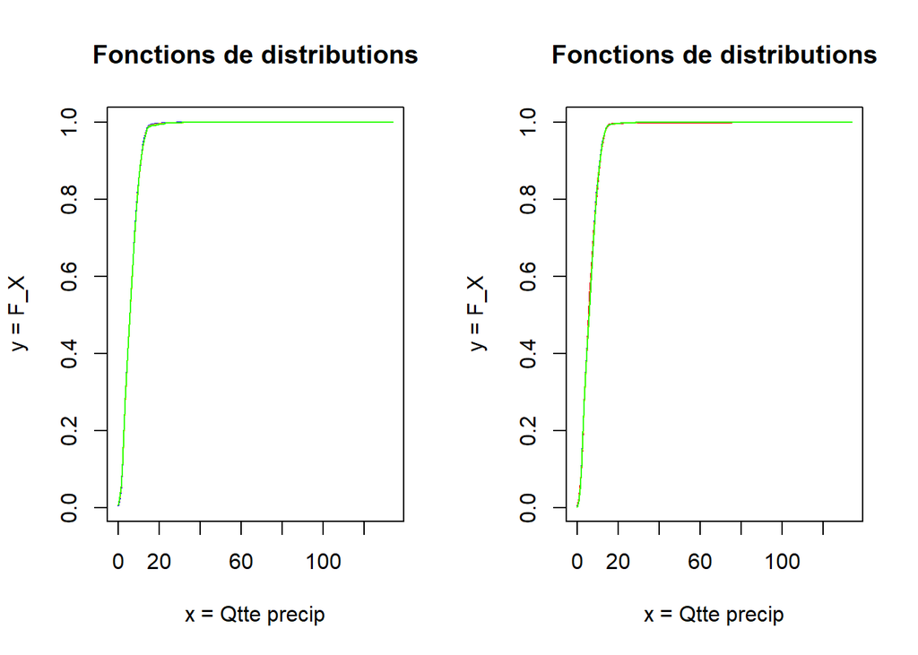

```r
layout(matrix(1:2,1,2))

plot(x,CDF_etp_series$ref(x),xlab="x = Qtte precip", ylab="y = F_X", type="l",col="blue", main= "Fonctions de distributions")
for (i in 2:5){
  eval(parse(text=paste("y <- CDF_etp_series[[",i,"]]","(x)",sep="")))
  lines(x,y, col = colors[i-1])
}

plot(x,CDF_etp_series$ref(x),xlab="x = Qtte precip", ylab="y = F_X", type="l",col="blue", main= "Fonctions de distributions")
for (i in 6:9){
  eval(parse(text=paste("y <- CDF_etp_series[[",i,"]]","(x)",sep="")))
  lines(x,y, col = colors[i-5])
}
```

On n’y voit pas grand chose, peut être que ce n’est pas pertinent.

### Test de Cramer-von Mises

```r
source(paste(loc,"/codes_utiles/test_stat_Cramer_von_Mises.R",sep=""))
```

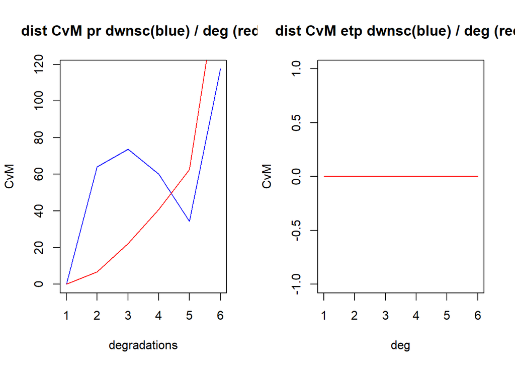

```r
#On applique l'algorithme de Cramer-von Mises
CVM_pr_series<-function(serie){return(cvm(serie,pr_series[,1],TRUE))}
CVM_etp_series<-function(serie){return(cvm(serie,etp_series[,1],TRUE))}
pr_CVM<-apply(pr_series, 2, CVM_pr_series)
etp_CVM<-apply(etp_series, 2, CVM_etp_series)
#CVM$T # donne la valeur de la "distance" entre les cdfs
#CVM$pval # p-value du test CvM
pr_CVM_stat<-matrix(0,1,11)
etp_CVM_stat<-matrix(0,1,11)
for (i in (1:11)){
  pr_CVM_stat[i]<-pr_CVM[[i]]$T
  pr_CVM_stat[i]<-pr_CVM[[i]]$T
}
colnames(pr_CVM_stat)<-c("ref", "dwnsc(x9)", "dwnsc(x25)", "dwnsc(x49)", "dwnsc(x81)", "dwnsc IPSL",  "deg(x9)", "deg(x25)", "deg(x49)", "deg(x81)", "IPSL")
colnames(etp_CVM_stat)<-c("ref", "dwnsc(x9)", "dwnsc(x25)", "dwnsc(x49)", "dwnsc(x81)", "dwnsc IPSL",  "deg(x9)", "deg(x25)", "deg(x49)", "deg(x81)", "IPSL")

layout(matrix(1:2,1,2))
plot(pr_CVM_stat[,(1:6)], main= "dist CvM pr dwnsc(blue) / deg (red)", xlab="degradations" , ylab="CvM", type="l", col="blue")
lines(pr_CVM_stat[,c(1,7,8,9,10,11)], col="red")
plot(etp_CVM_stat[,(1:6)], main= "dist CvM etp dwnsc(blue) / deg (red)", xlab="deg" , ylab="CvM", type="l")
lines(etp_CVM_stat[,c(1,7,8,9,10,11)], col="red")
```

La p-value n’est pas representative dans ce cas là. Celà est dû au fait que la précipitation possède une fonction de distribution avec une masse de Dirac en 0.

###Etude des jours de sécheresse

On va regarder pour chaque série les jours de sécheresse consécutifs

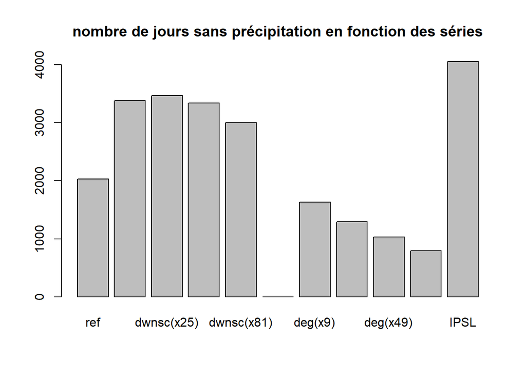

```r
drought_sum<-function(serie){return(sum(freq_without_rain(serie)))}
drought_serie_sum <- apply(pr_series, 2, drought_sum)

barplot(drought_serie_sum, main="nombre de jours sans précipitation en fonction des séries")
```

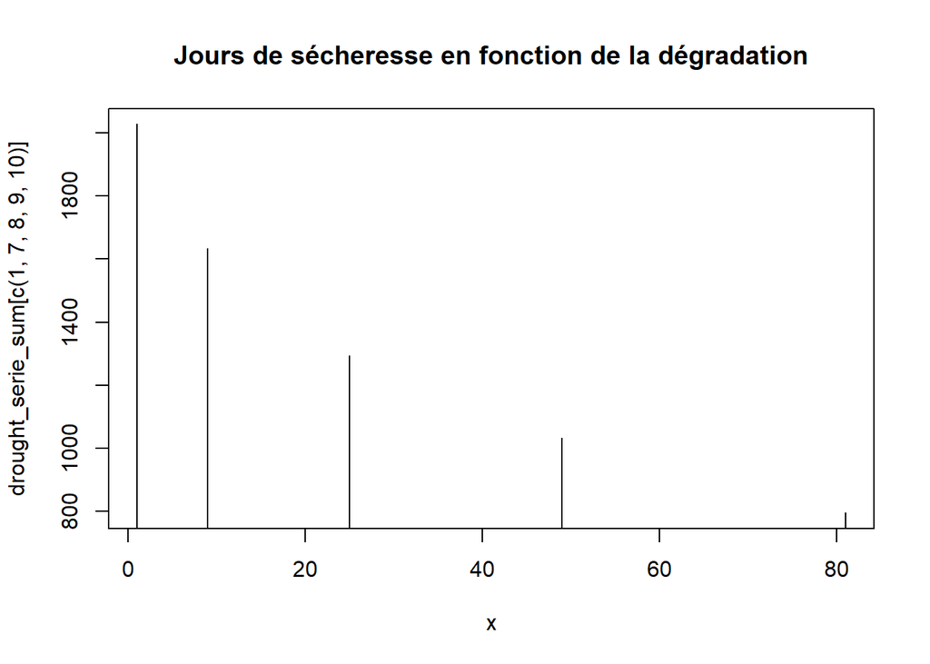

```r
x<-c(1,9,25,49,81)
plot(x,drought_serie_sum[c(1,7,8,9,10)], type = "h", main = "Jours de sécheresse en fonction de la dégradation", x_lab= "dégradation")
```

### Analyse des fréquence de jours secs d’affilés

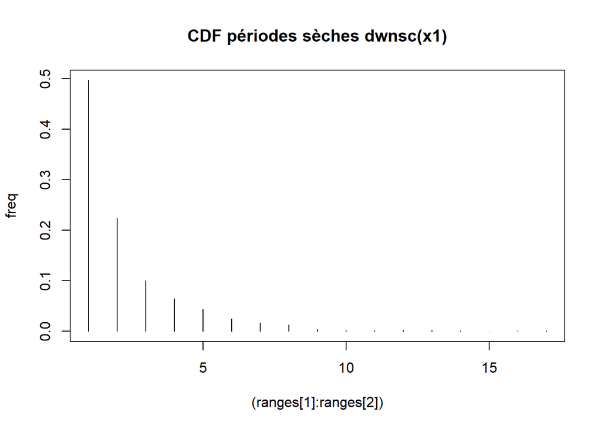

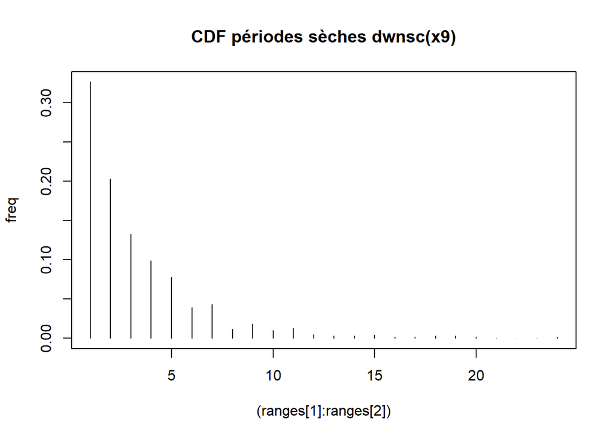

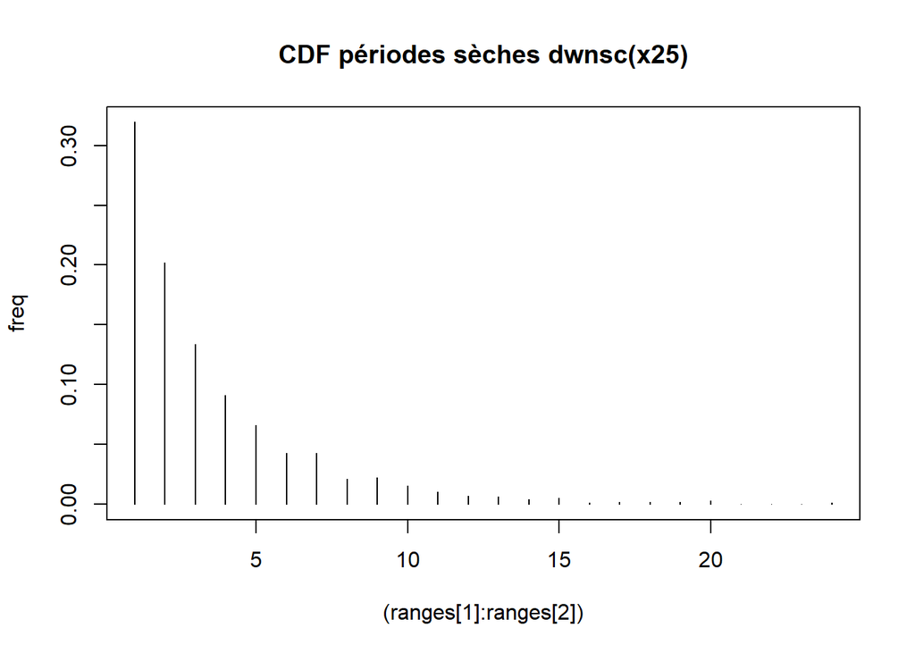

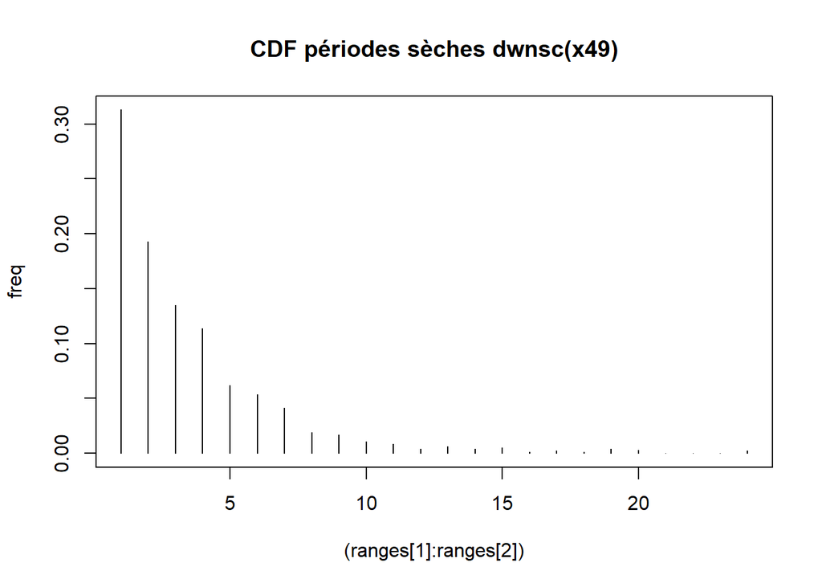

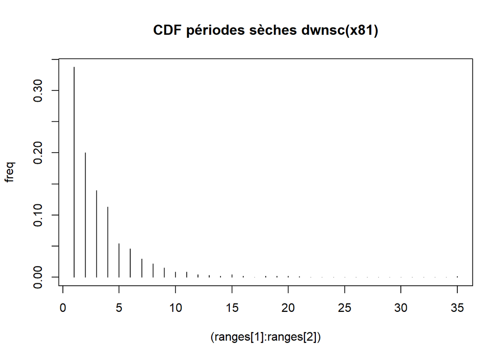

```r
freq<-function(serie,rg){
  frequences <-matrix(0,rg[2]-rg[1]+1,1)
  for (i in rg[1]:rg[2]){
    frequences[i-rg[1]+1,1]<-length(which(serie==i))
  }
  return (frequences/length(serie))
}


for (i in 1:5){
  serie<-freq_without_rain(pr_series[,i])
  ranges<-range(serie)
  plot((ranges[1]:ranges[2]),freq(serie,ranges), main= paste("CDF périodes sèches dwnsc(x", (2*(i-1)+1)^2, ")", sep=""), ylab="freq", type="h")
}
```

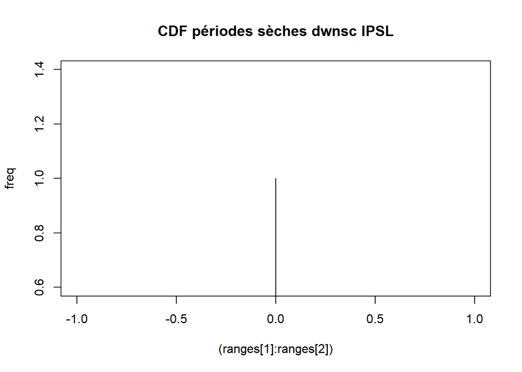

```r
serie<-freq_without_rain(pr_series[,6])
ranges<-range(serie)
plot((ranges[1]:ranges[2]),freq(serie,ranges), main= paste("CDF périodes sèches dwnsc IPSL"), ylab="freq", type="h")
```

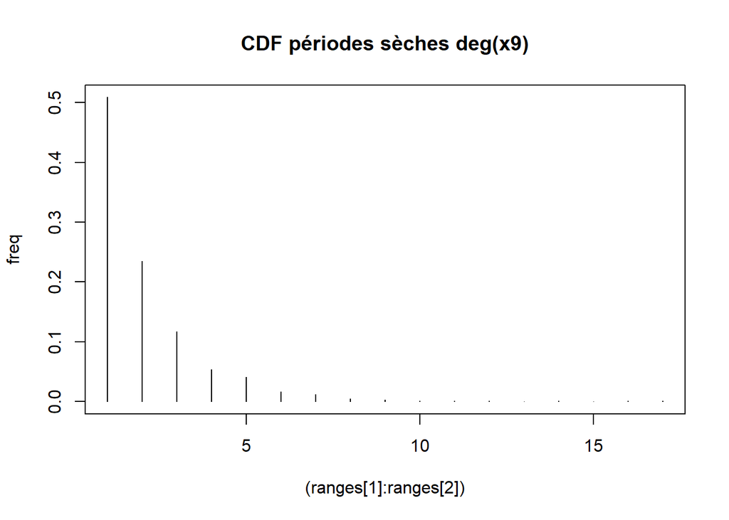

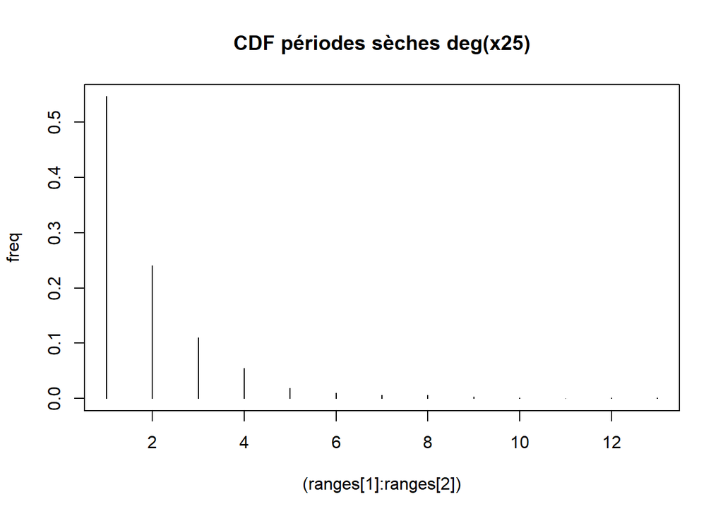

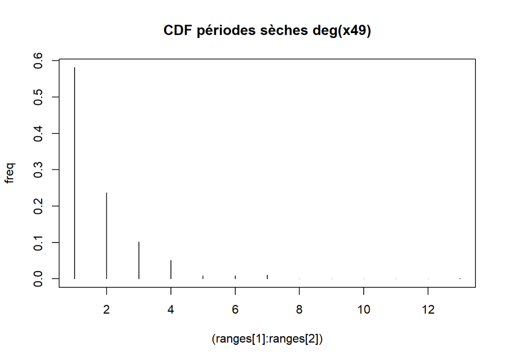

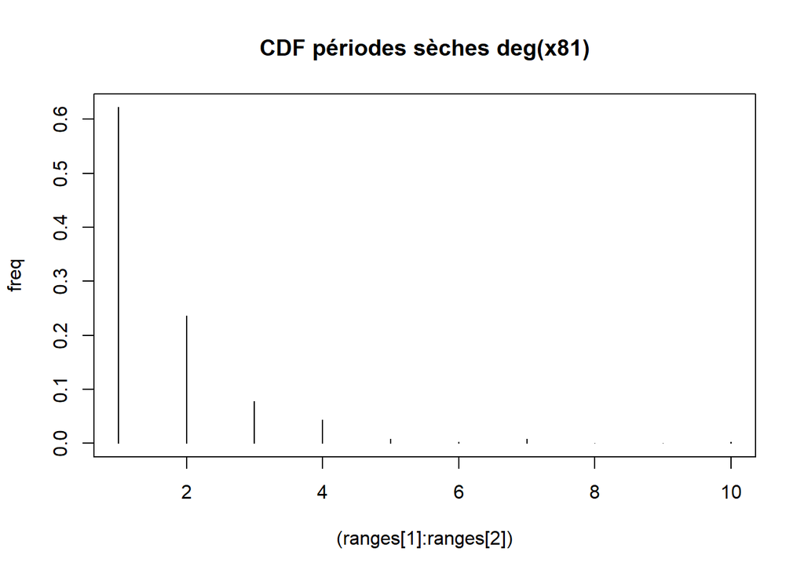

```r
for (i in c(7,8,9,10)){
  serie<-freq_without_rain(pr_series[,i])
  ranges<-range(serie)
  plot((ranges[1]:ranges[2]),freq(serie,ranges), main= paste("CDF périodes sèches deg(x", (2*(i-6)+1)^2, ")", sep=""), ylab="freq", type="h")
}
```

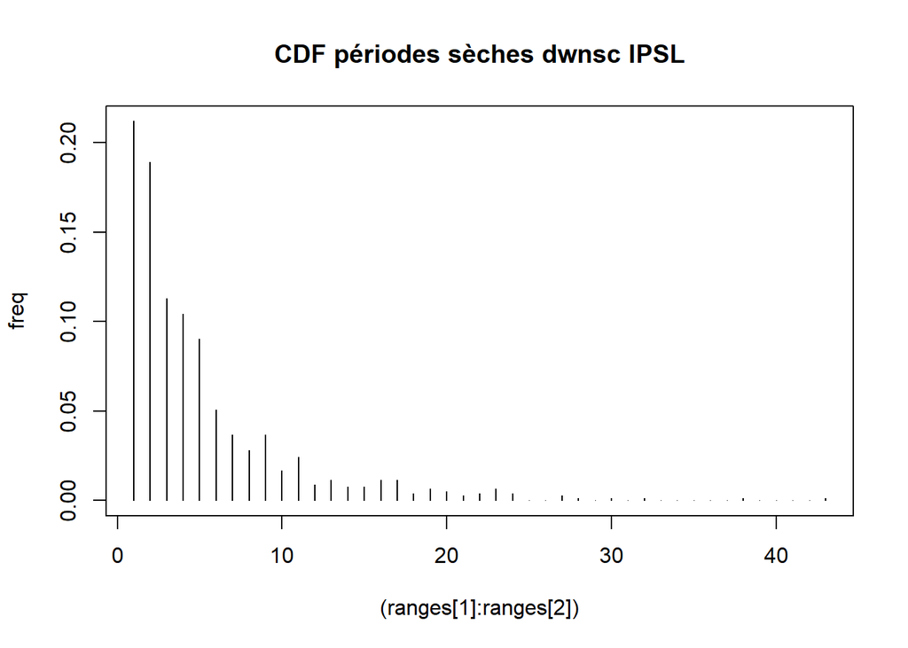

```r
serie<-freq_without_rain(pr_series[,11])
ranges<-range(serie)
plot((ranges[1]:ranges[2]),freq(serie,ranges), main= paste("CDF périodes sèches dwnsc IPSL"), ylab="freq", type="h")
```

## Autre méthode de downscaling CDFt_norm pour la série de précipitation

Nous allons essayer ici une nouvelle méthode de downscaling

### Regression linéaire pour définir nos fonctions f et g

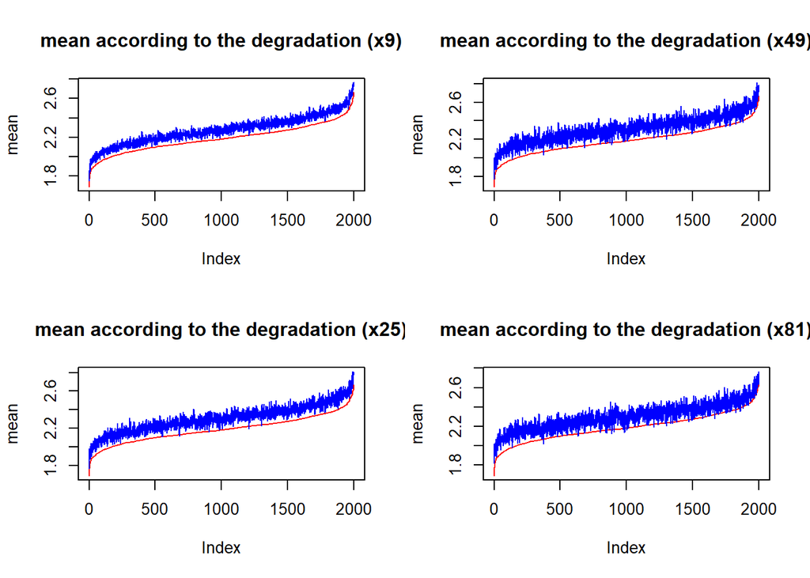

```r
n<-2000

Mu<-matrix(0,n,11)
Sigma<-matrix(0,n,11)
mu_series<-function(pr_serie){
  return (apply(sous_part(pr_series),2,mean))
}
sigma_series<-function(pr_serie){
  return (apply(sous_part(pr_series),2,var))
}

##############################  Attention #####################################################
# On ne veut pas l'appliquer sur les séries downscalées mais sur les séries réelles dégradées.#
###############################################################################################
for (i in 1:n){
  Mu[i,]<-mu_series(pr_series)
  Sigma[i,]<-sigma_series(pr_serie)
}

layout(matrix(1:4,2,2))
ord<-order(Mu[,1])
for (i in 2:6){
  plot(Mu[ord,1],col="red",type="l", main=paste("mean according to the degradation (x",(2*(i-1)+1)^2,")", sep=""), ylim = range(rbind(range(Mu[,1]),range(Mu[,i]))), ylab = "mean")
  lines(Mu[ord,i],col="blue")
}
```

```r
#On voit ici qu'il faut prévoire à partir des quantiles
```

[figure not shown]

### Construction des modèles

On commence par importer les modèles d’apprentissage

```r
serie_prec_ref <- read.csv(paste(loc,"/series/precp_ref_1979_2014.csv",sep=""))[,2]
degraded_prec1 <- read.csv(paste(loc,"/series/precp_deg1_1979_2014.csv",sep=""))[,2]
degraded_prec2 <- read.csv(paste(loc,"/series/precp_deg2_1979_2014.csv",sep=""))[,2]
degraded_prec3 <- read.csv(paste(loc,"/series/precp_deg3_1979_2014.csv",sep=""))[,2]
degraded_prec4 <- read.csv(paste(loc,"/series/precp_deg4_1979_2014.csv",sep=""))[,2]


pr_series2<-matrix(0, length(serie_prec_ref),5)
pr_series2[,1]<-serie_prec_ref
pr_series2[,2]<-degraded_prec1
pr_series2[,3]<-degraded_prec2
pr_series2[,4]<-degraded_prec3
pr_series2[,5]<-degraded_prec4
colnames(pr_series2)<-c("ref", "deg (x9)", "deg (x25)", "deg (x49)", "deg (x81)")
```

#On les sous echantillons pour évaluer la moyenne

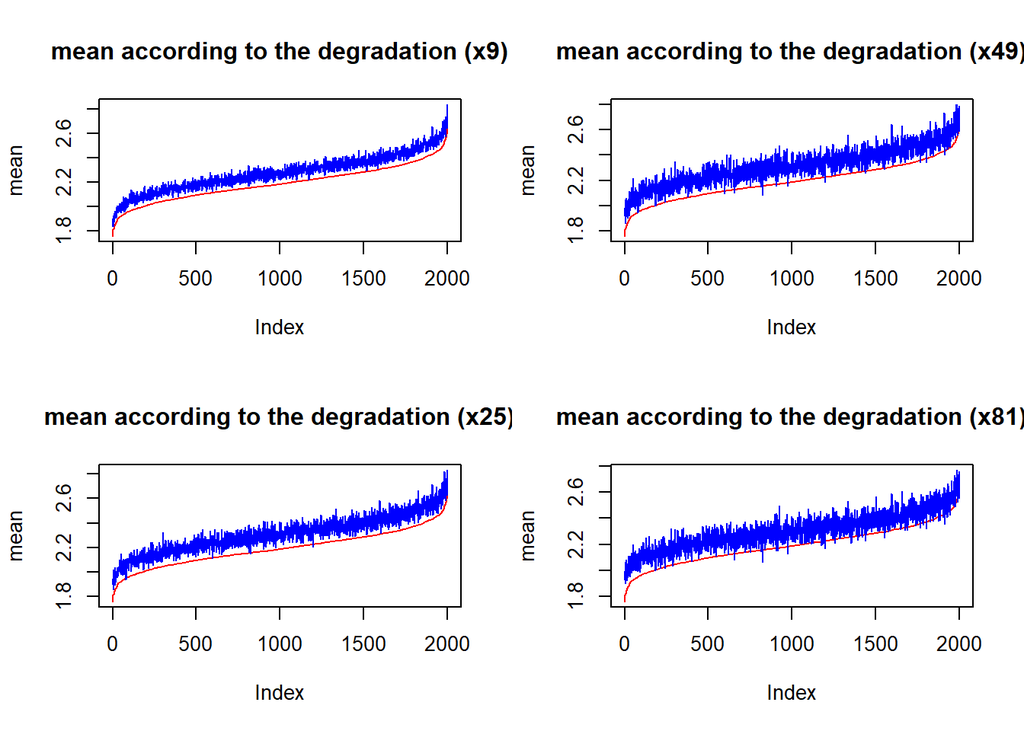

```r
n<-2000

Mu<-matrix(0,n,11)
Sigma<-matrix(0,n,11)
mu_series<-function(pr_serie){
  return (apply(sous_part(pr_serie),2,mean))
}
sigma_series<-function(pr_serie){
  return (apply(sous_part(pr_serie),2,var))
}

for (i in 1:n){
  Mu[i,]<-mu_series(pr_series)
  Sigma[i,]<-sigma_series(pr_series)
}

layout(matrix(1:4,2,2))
ord<-order(Mu[,1])
for (i in 2:5){
  plot(Mu[ord,1],col="red",type="l", main=paste("mean according to the degradation (x",(2*i-1)^2,")", sep=""), ylim = range(rbind(range(Mu[,1]),range(Mu[,i]))), ylab = "mean")
  lines(Mu[ord,i],col="blue")
}
```

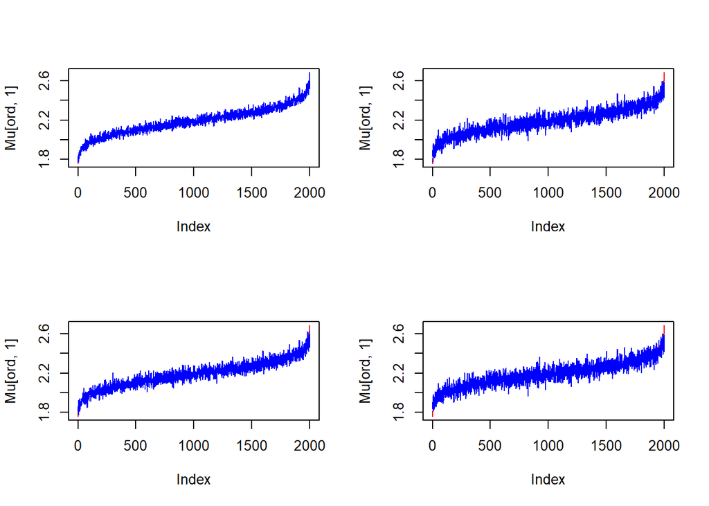

```r
model.mu<-function(Mu1){
  Mu2<-Mu1^2
  return(lm(Mu[,1] ~ Mu1 + Mu2))}

model.sigma<-function(sigma1){
  sigma2<-sigma1^2
  return(lm(Sigma[,1] ~ sigma1 +sigma2))}
models.mean<-list()
models.sigma<-list()
for (i in 2:5){
  Mu1<-Mu[,i]
  Mu2<-Mu1^2
  Sigma1<-Sigma[,i]
  Sigma2<-Sigma1^2
  models.mean[[i-1]]<- lm(Mu[,1]~Mu1+Mu2)
  models.sigma[[i-1]]<- lm(Sigma[,1]~Sigma1+Sigma2)
}
#On définit nos modèles

layout(matrix(1:4,2,2))
for (i in 1:4){
  Mu1<-Mu[,i+1]
  Mu2<-Mu1^2
  ord<-order(Mu[,1])
  plot(Mu[ord,1],type="l", col= "red")
  lines(models.mean[[i]]$coefficients[1]+models.mean[[i]]$coefficients[2]*Mu1[ord]+models.mean[[i]]$coefficients[3]*Mu2[ord], type= "l", col= "blue")
}
```

### On va maintenant définir les fonctions f et g pour chaque dégradation

```r
liste.f.g<-list()
for(i in 1:4){
  f<-function(x){
    return(models.mean[[i]]$coefficients[1]+models.mean[[i]]$coefficients[2]*x+ models.mean[[i]]$coefficients[3]*x^2)
  }
  g<-function(x){
    return(models.sigma[[i]]$coefficients[1]+models.sigma[[i]]$coefficients[2]*x+ models.sigma[[i]]$coefficients[3]*x^2)
  }
  liste.f.g[[i]]<-f
  liste.f.g[[i+4]]<-g
}
```

### L’objectif est maintenant d’appliquer CDFt_norm pour observer ses résultats

```r
# ### Regardons si c'est pertinent d'ajuster la variance et la moyenne de nos séries
#
# #On va créer une fonction qui ajuste la moyenne et la variance
# ajust<-function(serie_ds,f,g){
#   return(serie_ds*g(var(serie_ds))/var(serie_ds))
# }
#
# pr_series_ajust<-matrix(0, length(pr_ref),5)
# pr_series_ajust[,1]<-pr_series[,1]
# for (i in 1:4){
#   pr_series_ajust[,i+1]<-ajust(pr_series[,i+1],liste.f.g[[i]],liste.f.g[[i+4]])
# }
#
# Mu_ajust<-matrix(0,n,5)
# Sigma_ajust<-matrix(0,n,5)
# for (i in 1:n){
#   Mu_ajust[i,]<-mu_series(pr_series_ajust)
#   Sigma_ajust[i,]<-sigma_series(pr_series_ajust)
# }
#
# ala<-mu_series(pr_series_ajust)
# layout(matrix(1:4,2,2))
# for (i in 2:5){
#   ord<-order(Mu_ajust[,1])
#   plot(Mu_ajust[ord,1],col="red",type="l", main=paste("mean according to the degradation (x",(2*(i-1)+1)^2,")", sep=""), ylim = range(rbind(range(Mu[,1]),range(Mu[,i]))))
#   lines(Mu_ajust[ord,i],col="blue")
# }
```

## Algorithme CDFt_norm

Il faut encore travailler cet algorithme qui ne compile pas encore.

```r
# #on commence par réappliquer le résulats
# downscal_appli(loc, "CDFt_norm" , D_proj, liste.f.g)
#
#
# pr_ds1 <- read.csv("./series/pr_ds1.csv")[,2]
# pr_ds2 <- read.csv("./series/pr_ds2.csv")[,2]
# pr_ds3 <- read.csv("./series/pr_ds3.csv")[,2]
# pr_ds4 <- read.csv("./series/pr_ds4.csv")[,2]
#
# #Precipitation
# pr_series_n<-matrix(0, length(pr_ref),5)
# pr_series_n[,1]<-pr_ref
# pr_series_n[,2]<-pr_ds1
# pr_series_n[,3]<-pr_ds2
# pr_series_n[,4]<-pr_ds3
# pr_series_n[,5]<-pr_ds4
# colnames(pr_series_n)<-c("ref", "deg (x9)", "deg (x25)", "deg (x49)", "deg (x81)")
#
# summary(pr_series_n)
```

```r
# #Comparaison des RMSE
#
# pr_RMSE_n <- apply(pr_series_n,2,fun_pr)
#
# plot(c(1,9,25,49,81),pr_RMSE, type="o", main="RMSE precipitation", ylab = "RMSE", xlab= "degradation", col = "blue")
# lines(c(1,9,25,49,81), pr_RMSE_n,  col = "blue")
```